# 24.09.10_Evaluación Módulo 9

Cristóbal León-Salas

2024-09-10

# 1 Carga de librerías

Se cargan todas las librerias que van a ser usadas durante el ejercicio:

```r
suppressPackageStartupMessages({
           library(udpipe) # Para el análisis lingüístico
           library (dplyr)
           library(lattice)
           library(textrank)
           library(kableExtra)
           library(igraph)
           library(ggraph)
           library(wordcloud)
           library(visNetwork)
           library(text2vec) # Para Modelo Glove
           library(Rtsne)
           library(ggplot2)
           library(ggrepel)
           library(ggiraph) # Para gráfico interactivo visualización word embeddings
           library(ROSE) #Para el balanceo
           library(caret)
           library(stringr)
           library(fastrtext) # Para el modelo de clasificación de textos
           library(reticulate) # Permite interactuar entre R y Python
                    })
```

# 2 Carga de datos

Se procede a la carga de los datos contenidos en el arhivo: evaluacion.RData.

El archivo `evaluacion.RData` contiene dos dataframes:  
- **prado**: Cuenta Twitter del Museo del Prado, con 1,158 tuits (desde 01-01-2021 al 30-06-2022).  
- **reviews**: Contiene 13,241 críticas sobre el alojamiento en diversas ciudades de Andalucía.

```r
load("evaluacion.RData")

# Se observa que el archivo contiene dos dataframes, cuyas dimensiones son las siguientes:

print(paste("El dataframe llamado prado contiene", dim (prado)[1], "filas y", dim (prado)[2], "columnas."))
```

```
## [1] "El dataframe llamado prado contiene 1158 filas y 2 columnas."
```

```r
print(paste("El dataframe llamado reviews contiene", dim (reviews)[1], "filas y", dim (reviews)[2], "columnas."))
```

```
## [1] "El dataframe llamado reviews contiene 13241 filas y 3 columnas."
```

# 3 Funciones

```r
similitudes <- function(w, n=5){ #Se define una función llamada similitudes que toma dos argumentos: w, que es la palabra para la cual se calcularán las similitudes, y n, que es el número de palabras más similares a devolver (por defecto es 5).
    wv <- word_vectors[w, , drop = FALSE] #Se extrae el vector de palabras correspondiente a la palabra w del conjunto de vectores de palabras word_vectors.
    cos_sim <- sim2(x = word_vectors, y = wv, method = "cosine", norm = "l2") #Se calcula la similitud de coseno entre todos los vectores de palabras (word_vectors) y el vector de palabras wv utilizando la función sim2. El método utilizado es “cosine” y la normalización es “l2”.
    head(sort(cos_sim[,1], decreasing = TRUE), n) #Se ordenan las similitudes de coseno en orden descendente y se seleccionan las n palabras más similares utilizando la función head.
}
```

# 4 PREGUNTA 1: Text Mining - dataframe prado

Según el enunciado, la descripción de las columnas del dataframe “prado” es el siguiente:  
- **created_at**: Fecha de publicación del tuit. Desde el 01‐01‐2021 hasta el 30‐06‐2022.  
- **text**: El texto del tuit.

## 4.1 Limpieza del texto

Para realizar text mining al texto de los tuits, es importante depurar previamente el texto.  
Como por ejemplo, eliminar: usuarios de Twitter, hashtags, URLs,…  
Para realizar la limpieza del texto, podemos utilizar el siguiente script:

```r
# === Limpieza de Texto ===
prado$textmining <- prado$text
# Quitar "@usuario"
prado$textmining <- gsub("@\\w+", "", prado$textmining) # La función gsub en R es utilizada para buscar patrones de texto específicos dentro de un string o vector de strings y reemplazarlos por otro texto
# Quitar "#hashtag"
prado$textmining <- gsub("#\\w+", "", prado$textmining)
# Quitar "URL"
prado$textmining <- gsub("http[^[:blank:]]*", "", prado$textmining)
# Quitar "e-Mail"
prado$textmining <- gsub("\\w+@\\w+.\\w+", "", prado$textmining)
# Si fuera necesario, añadir espacio después de "punto","coma","punto y coma","dos puntos"
prado$textmining <- gsub("([.]|,|;|:)([[:alpha:]])", "\\1 \\2", prado$textmining)
# Conservar letras, dígitos, espacios en blanco, saltos de línea y caracteres de puntuación
prado$textmining <- gsub("[^[:alpha:][:digit:][:space:][:punct:]]*", "", prado$textmining)
# Eliminar espacios en blanco sobrantes
prado$textmining <- gsub("\\s{2,}", " ", prado$textmining)
# Elimino signos de puntuación
prado$textmining <- gsub("[\\?¿\"'-:ºª;,.¡!@#$%&/()='_+*{}<>^~|\\\\`‘–…’€]", "", prado$textmining)
# Otros
prado$textmining <- gsub("⬇️", "", prado$textmining)

# Quitar espacios en blanco al inicio y final del texto
prado$textmining <- trimws(prado$textmining) # La función trimws en R se utiliza para eliminar los espacios en blanco al principio y al final de una cadena de texto. Esta función es especialmente útil cuando se trabaja con datos de texto y se desea limpiar cualquier espacio extra que pueda haberse introducido accidentalmente. Aquí, trimws se aplica a la columna textmining del dataframe prado, eliminando cualquier espacio en blanco al inicio y al final de cada cadena de texto en esa columna.
```

## 4.2 Análisis lingüístico

### 4.2.1 Eliminación de stop-words:

Antes de comenzar con el análisis lingüístico, es conveniente eliminar del corpus ciertas palabras, locuciones o expresiones de uso común, que no aportan información significativa sobre el contenido del texto y pueden sesgar los resultados si no se eliminan. De modo que:

```r
# Crear una lista de stopwords en español e inglés
stopwords <- c(
  # Expresiones comunes
  "sin embargo", "however", "sin duda", "without a doubt", "sin ninguna duda",
  "undoubtedly", "sin lugar a dudas","así", "like this", "like that",
  "de esta manera", "de ese modo", "de esa manera", "this way",
  "that way", "tal", "such", "no doubt", "a simple vista", "at first glance",
  "a primera vista", "at first sight", "punto de vista", "point of view",
  "tal vez", "perhaps", "maybe", "por primera vez", "for the first time",
  "por última vez", "for the last time", "a la vez", "at the same time",
  "al mismo tiempo", "simultaneously", "por supuesto", "of course",
  "al final", "in the end", "gracias a", "thanks to", "gracias al", "thanks to the",
  "a pesar de", "despite", "in spite of", "por otra parte", "on the other hand",
  "por su parte", "for its part", "en gran parte", "in great part", "gran parte de",
  "a large part of", "gran parte del", "a large part of the", "mayor parte", "most",

  # Conjunciones
  "y", "and", "o", "or", "pero", "but", "aunque", "although", "sino", "but", "ni", "nor",
  "que", "that", "como", "like", "as",

  # Pronombres
  "yo", "I", "tú", "you", "él", "he", "ella", "she", "nosotros", "we", "vosotros", "you",
  "ellos", "they", "ellas", "they", "me", "me", "te", "you", "se", "himself", "nos", "us", "os", "you all",

  # Pronombres posesivos
  "mi", "my", "mis", "my", "tu", "your", "tus", "your", "su", "his", "sus", "their", "nuestro", "our",
  "nuestra", "our", "nuestros", "our", "nuestras", "our", "vuestro", "your", "vuestra", "your",
  "vuestros", "your", "vuestras", "your", "mine", "yours", "theirs", "ours",

  # Adverbios
  "muy", "very", "ya", "already", "aquí", "here", "allí", "there", "ahora", "now", "aún", "still",
  "más", "more", "menos", "less", "casi", "almost", "bastante", "quite", "antes", "before",

  # Determinantes demostrativos
  "este", "esta", "estos", "estas", "that", "this", "these", "those",
  "ese", "esa", "esos", "esas", "that", "those",
  "aquel", "aquella", "aquellos", "aquellas",

  # Otros
  "también", "also", "too", "entonces", "then", "además", "besides", "moreover",
  "luego", "later", "siempre", "always", "nunca", "never", "bien", "well", "mal", "badly",
  "si", "if", "qué", "solo", "only", "etcétera", "etc", "and so on", "et cetera"
)


# Crear el patrón de expresión regular uniendo las palabras con "|"
pattern <- paste0("\\b(", paste(stopwords, collapse = "|"), ")\\b")

# Usar gsub para eliminar las stopwords en un solo paso, ignorando mayúsculas y minúsculas
prado$textmining <- gsub(pattern, "", prado$textmining, ignore.case = TRUE)
```

### 4.2.2 Eliminación letras sueltas:

Termino por eliminar aquellas “palabras” compuestas por una única letra y que, en realidad, no aportan información alguna:

```r
prado$textmining <- gsub("\\b[a-zA-Z]\\b", "", prado$textmining)

prado$textmining <- trimws(prado$textmining)
prado$textmining<- gsub("\\s{2,}", " ", prado$textmining) #Reemplaza dos o mas espacios
```

### 4.2.3 Análisis

```r
model <- udpipe_load_model(file = "spanish-gsd-ud-2.5-191206.udpipe")
x <- udpipe(x = prado$textmining, model, parallel.cores = parallel::detectCores(), parser = "none")
x <- as.data.frame(x)
x$lemma <- tolower(x$lemma)

# Comprobación que no quedan signos de puntuación en el dataframe x:
P = x %>% filter(upos == "PUNCT")
nrow(P)
```

```
## [1] 0
```

```r
# Como P no tiene filas, se comprueba que no existen ya signos de puntuación en ninguna de las observaciones.

# Compruebo si hubiera algún lema etiquetado como "X" que pudiera ser relevante. El valor X en la columna upos indica que la palabra no se puede clasificar en ninguna de las categorías gramaticales estándar. Esto puede ocurrir por varias razones, como errores en el texto, palabras desconocidas o elementos que no encajan en las categorías tradicionales.

x %>% filter(upos == "X") %>% group_by(lema=lemma) %>%
      summarize(freq=n(), .groups = "drop") %>% arrange(-freq) %>% head(20)
```

```
## # A tibble: 10 × 2
##    lema          freq
##    <chr>        <int>
##  1 online           7
##  2 am               5
##  3 boj              4
##  4 ies              2
##  5 eso              1
##  6 gigapixel        1
##  7 inscribiro       1
##  8 instagram        1
##  9 mecena           1
## 10 sociabilidad     1
```

```r
# Destaca la palabra "online", la cual genera dudas, puesto que puede funcionar tanto como sustantivo y como adjetivo:

obs_online = x %>% filter(tolower(x$token) == "online") %>% select (sentence)

# Se comprueba que todas las observaciones referidas a la palabra "online"actuán como adjetivo. Por tanto:

x$upos[tolower(x$token) == "online"] <- "ADJ"
```

## 4.3 Términos más frecuentes

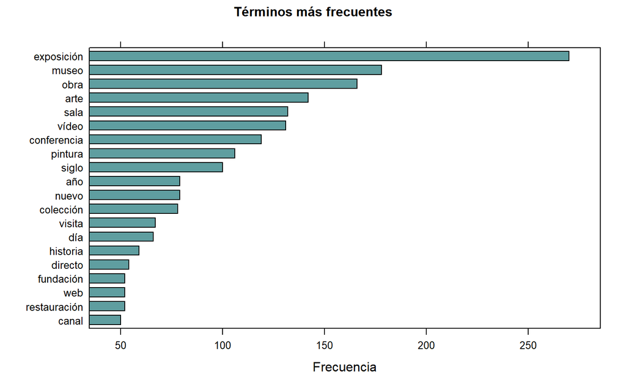

```r
# Busco los términos frecuentes entre los sustantivos y adjetivos

terminos <- subset(x, upos %in% c("NOUN", "ADJ"))
terminos <- txt_freq(terminos$lemma)
terminos$key <- factor(terminos$key, levels = rev(terminos$key))
barchart(key ~ freq, data = head(terminos, 20), col = "cadetblue",
         main = list("Términos más frecuentes", cex="1"), xlab = "Frecuencia")
```

```r
# Se observa que las palabras que tienen como lema "exposión" destacan sobre el resto por su frecuencia. También destacar los lemas "museo" y "obra"
```

## 4.4 Palabras clave

### 4.4.1 Rake

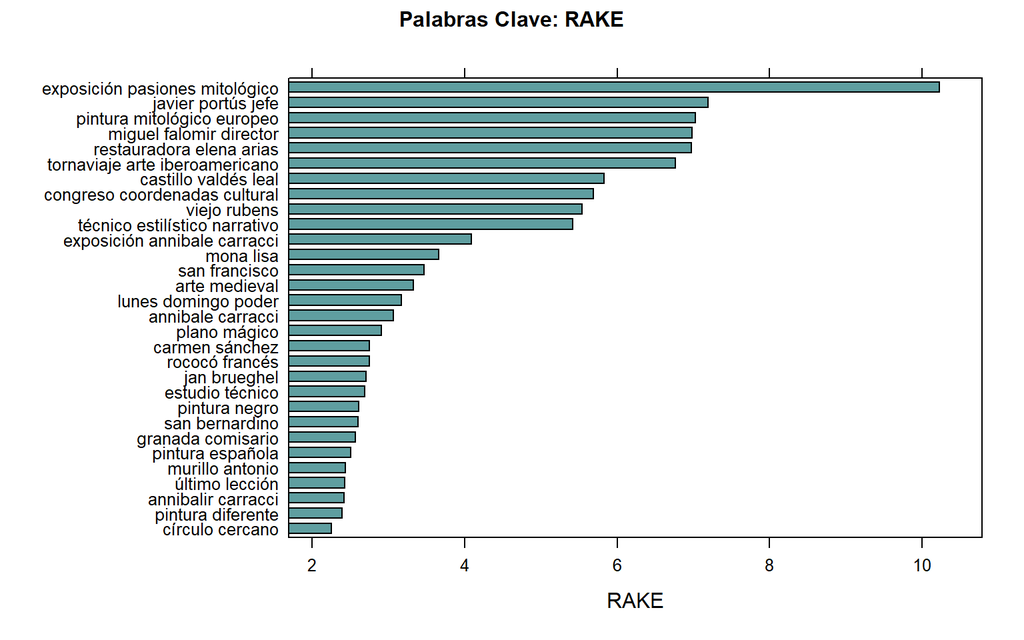

```r
# El enunciado indica lo siguiente: "Además de sustantivos y adjetivos, plantéate incluir nombres propios"

# RAKE (Rapid Automatic Keyword Extraction) es un algoritmo utilizado para la extracción de palabras clave de un texto. Es un método no supervisado que identifica las palabras clave más relevantes basándose en la frecuencia de aparición y la co-ocurrencia de palabras dentro del texto.

#Co-ocurrencia: la co-ocurrencia se refiere a la frecuencia con la que dos o más palabras aparecen juntas en un corpus de texto, como una colección de páginas web o documentos.

kwrake <- keywords_rake(x, term = "lemma", group = "doc_id",
                        relevant = x$upos %in% c("NOUN", "ADJ","PROPN"), ngram_max = 3)

# ngram_max especifica el número máximo de palabras que puede tener cada palabra clave extraída, es decir, por aquello de la co-ocurrencia.

kwrake <- subset(kwrake, freq > 5 & ngram > 1)
kwrake$key <- factor(kwrake$keyword, levels = rev(kwrake$keyword))
barchart(key ~ rake, data = head(kwrake,30), col = "cadetblue",
         main = list("Palabras Clave: RAKE", cex="1"), xlab = "RAKE")
```

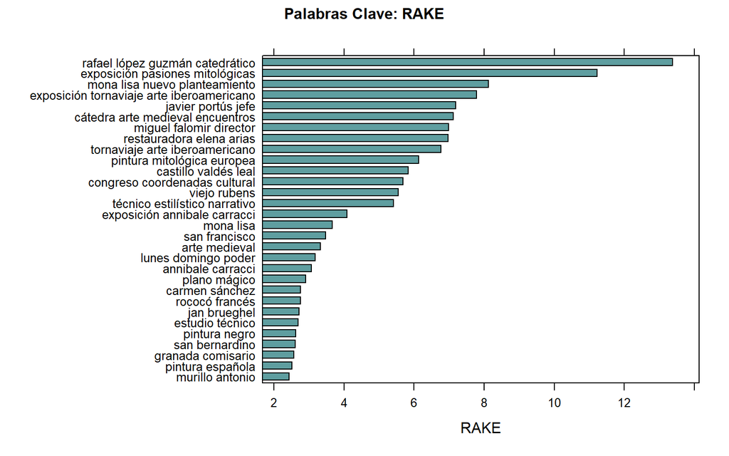

```r
# Destaca sobre todos el término exposición pasiones mitológico

# Modifico el lema de los términos "exposición pasiones mitológico", "pintura motológico", "tecnico estilístico narrativo", "pintura negro", "granada comisario"

x$token_anterior <- txt_previous(x$token, n = 1)
x$token_siguiente <- txt_next(x$token, n = 1)

x$lemma[tolower(x$token) == "mitológicas" & tolower(x$token_anterior) == "pasiones"] <- "mitológicas"
x$lemma[tolower(x$token) == "mitológica" & tolower(x$token_anterior) == "pintura"] <- "mitológica"
x$lemma[tolower(x$token) == "europea" & tolower(x$token_anterior) == "mitológica"] <- "europea"
x$lemma[tolower(x$token) == "técnica" & tolower(x$token_siguiente) == "estilística"] <- "técnica"
x$lemma[tolower(x$token) == "estilística" & tolower(x$token_anterior) == "técnica" & tolower(x$token_siguiente) == "narrativa"] <- "estilística"
x$lemma[tolower(x$token) == "narrativa" & tolower(x$token_anterior) == "estilística"] <- "narrativa"
x$lemma[tolower(x$token) == "negra" & tolower(x$token_anterior) == "pintura"] <- "negra"
x$lemma[tolower(x$token) == "comisaría" & tolower(x$token_anterior) == "granada"] <- "comisaría"

# Es reseñable que aparecen muchos nombres con apellidos. Es por ello que voy aumentar el número de palabras máximas a 5 para obtener una mayor precisión:

kwrake <- keywords_rake(x, term = "lemma", group = "doc_id",
                        relevant = x$upos %in% c("NOUN", "ADJ","PROPN"), ngram_max = 5)

kwrake <- subset(kwrake, freq > 5 & ngram > 1)
kwrake$key <- factor(kwrake$keyword, levels = rev(kwrake$keyword))
barchart(key ~ rake, data = head(kwrake,30), col = "cadetblue",
         main = list("Palabras Clave: RAKE", cex="1"), xlab = "RAKE")
```

Una vez hecho el análisis con el algoritmo RAKE, pasamos al PMI

### 4.4.2 PMI

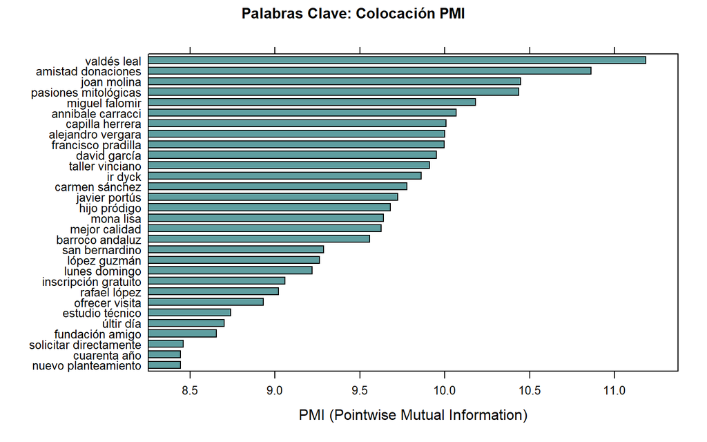

```r
# PMI es una medida utilizada para identificar la asociación entre dos palabras en un corpus de texto. Cuanto mayor sea el valor de PMI, más fuerte es la asociación entre las palabras

kwpmi <- keywords_collocation(subset(x, !(upos %in% c("SYM"))),
                              term = "lemma", group = "doc_id", n_min = 10)
kwpmi$key <- factor(kwpmi$keyword, levels = rev(kwpmi$keyword))
barchart(key ~ pmi, data = head(kwpmi,30), col = "cadetblue",
         main = list("Palabras Clave: Colocación PMI", cex="1"),
         xlab = "PMI (Pointwise Mutual Information)")
```

```r
# Destacan la asociación entre estas palabras "valdés y leal" y "amistad y donaciones". Como no puede ser de otra manera, destacan la importante cantidad de observaciones con nombres de personas (nombre + apellido).

x$lemma[tolower(x$token) == "gratuita" & tolower(x$token_anterior) == "inscripción"] <- "gratuita"
x$lemma[tolower(x$token) == "inscripciones" & tolower(x$token_siguiente) == "gratuitas"] <- "inscripciones"
x$lemma[tolower(x$token) == "gratuitas" & tolower(x$token_anterior) == "inscripciones"] <- "gratuitas"
```

### 4.4.3 Extracción de Frases

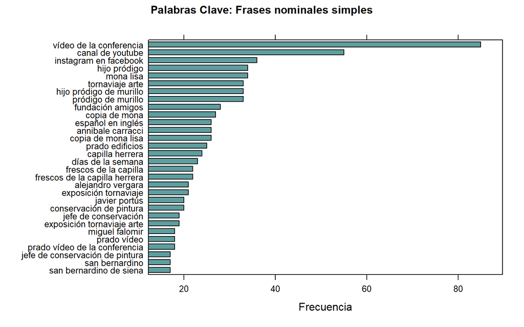

```r
x$phrase_tag <- as_phrasemachine(x$upos, type = "upos") #as_phrasemachine(x$upos, type = "upos"): Esta función toma un vector de etiquetas POS universales (upos) y las convierte en etiquetas de una sola letra.
# Etiqueto los pronombres y los números como "Otros elementos"

x$phrase_tag[x$upos=="PRON"] <- "O"
x$phrase_tag[x$upos=="NUM"] <- "O"

# Obtener frases nominales simples
kwphrases <- keywords_phrases(x$phrase_tag, term = tolower(x$token),
                              pattern = "(A|N)*N(P+D*(A|N)*N)*",
                              is_regex = TRUE, detailed = FALSE)
# is_regex = TRUE --> Indica que el patrón es una expresión regular, no una cadena literal.
# detailed = FALSE --> Si es FALSE, la función probablemente devuelve un resultado más simplificado, sin detalles adicionales.
kwphrases <- subset(kwphrases, freq > 5 & ngram > 1)
kwphrases$key <- factor(kwphrases$keyword, levels = rev(kwphrases$keyword))
barchart(key ~ freq, data = head(kwphrases,30), col = "cadetblue",
         main = list("Palabras Clave: Frases nominales simples", cex="1"), xlab = "Frecuencia")
```

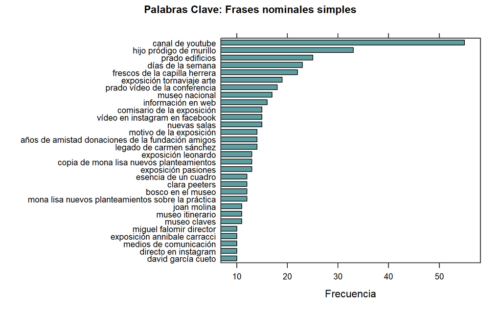

```r
# Destacan las frases "video de la conferencia" y "canal de youtube"

# Eliminamos las palabras clave que forman parte de otras palabras clave con más n-gramas.

v <- sapply(kwphrases$keyword, function(x) length(grep(x,kwphrases$keyword,value=TRUE)))
v <- v[v == 1]
kwphrases <- subset(kwphrases, keyword %in% names(v))

kwphrases$key <- factor(kwphrases$keyword, levels = rev(kwphrases$keyword))
barchart(key ~ freq, data = head(kwphrases,30), col = "cadetblue",
         main = list("Palabras Clave: Frases nominales simples", cex="1"), xlab = "Frecuencia")
```

```r
# Ahora la frase que destaca por su frecuencia sobre el resto es "canal de youtube"
```

### 4.4.4 TextRank

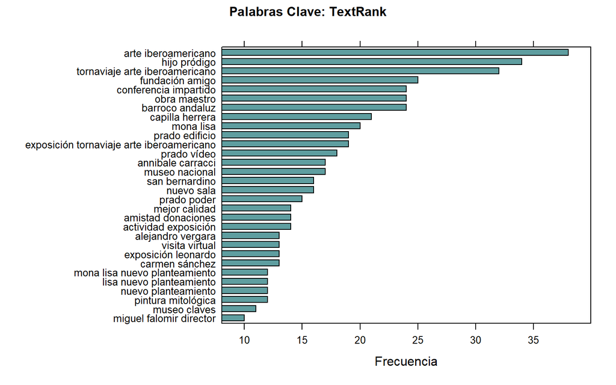

```r
kwtextrank <- textrank_keywords(x$lemma, relevant = x$upos %in% c("NOUN", "ADJ","PROPN"),
                                ngram_max = 8, sep = " ")
kwtextrank <- subset(kwtextrank$keywords, freq > 5 & ngram > 1)
kwtextrank$key <- factor(kwtextrank$keyword, levels = rev(kwtextrank$keyword))
barchart(key ~ freq, data = head(kwtextrank,30), col = "cadetblue",
         main = list("Palabras Clave: TextRank", cex="1"), xlab = "Frecuencia")
```

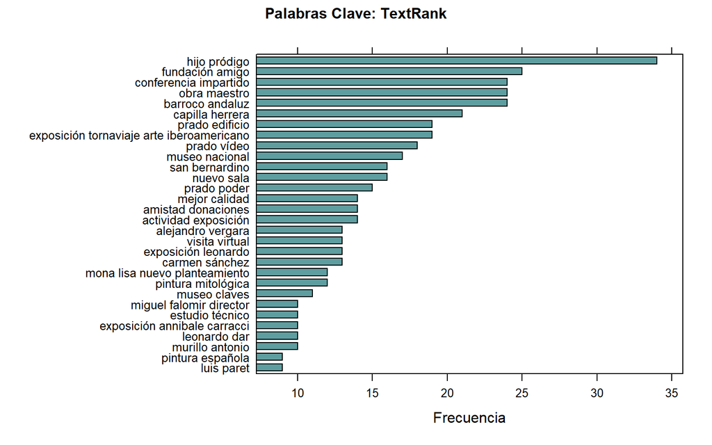

```r
x$lemma[tolower(x$token) == "impartida" & tolower(x$token_anterior) == "conferencia"] <- "impartida"
x$lemma[tolower(x$token) %in% c("maestra", "maestras") & tolower(x$token_anterior) %in% c("obra", "obras")] <- "maestra"
x$lemma[tolower(x$token) %in% c("nueva", "nuevas") & tolower(x$token_siguiente) %in% c("sala", "salas")] <- "nueva"

#Al igual que ocurriera anteriormente, eliminamos las palabras clave que forman parte de otras palabras clave con más n-gramas:

v <- sapply(kwtextrank$keyword, function(x) length(grep(x,kwtextrank$keyword,value=TRUE)))
v <- v[v == 1]
kwtextrank <- subset(kwtextrank, keyword %in% names(v))

kwtextrank$key <- factor(kwtextrank$keyword, levels = rev(kwtextrank$keyword))
barchart(key ~ freq, data = head(kwtextrank,30), col = "cadetblue",
         main = list("Palabras Clave: TextRank", cex="1"), xlab = "Frecuencia")
```

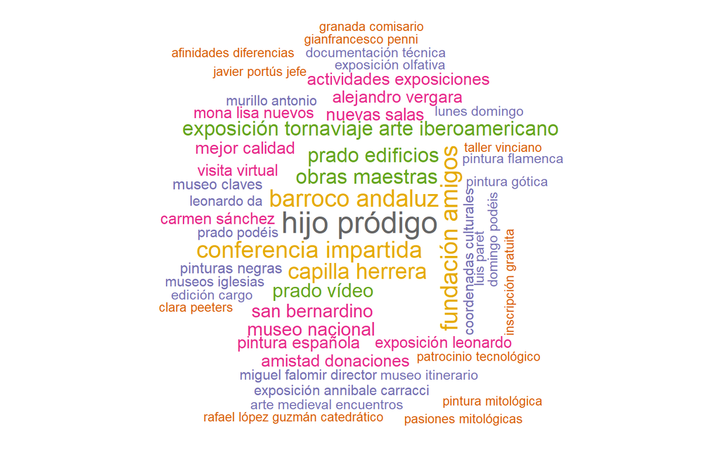

```r
# Una pálabra clave que se destaca es hijo pródigo, barroco andaluz, fundación amigos, capilla herrera y conferencia compartida

kwtextrank <- textrank_keywords(tolower(x$token), relevant = x$upos %in% c("NOUN", "ADJ","PROPN"),
                                ngram_max = 8, sep = " ")
kwtextrank <- subset(kwtextrank$keywords, freq > 7 & ngram > 1)
v <- sapply(kwtextrank$keyword, function(x) length(grep(x,kwtextrank$keyword,value=TRUE)))
v <- v[v == 1]
kwtextrank <- subset(kwtextrank, keyword %in% names(v))
kwtextrank$key <- factor(kwtextrank$keyword, levels = rev(kwtextrank$keyword))
wordcloud(words=kwtextrank$key, freq=kwtextrank$freq, scale=c(2,.5),
          random.order=F, colors=brewer.pal(8,"Dark2"))
```

## 4.5 Coocurrencias

```r
# Como se vió anteriormente las coocurrencias se refieren a la frecuencia con la que dos o más palabras aparecen juntas en un corpus de texto. De modo que:

terminos <- subset(x, upos %in% c("ADJ", "NOUN","PROPN"))
# Qué palabras están juntas
cooc_j <- data.frame(cooccurrence(terminos$lemma))
head(cooc_j, 20) %>% kbl(caption = "Principales concurrencias") %>% kable_minimal()
```

Principales concurrencias

| term1 | term2 | cooc |
| --- | --- | --- |
| museo | prado | 455 |
| vídeo | conferencia | 85 |
| canal | youtube | 55 |
| instagram | facebook | 40 |
| sala | museo | 38 |
| arte | iberoamericano | 38 |
| iberoamericano | españa | 38 |
| mona | lisa | 35 |
| hijo | pródigo | 34 |
| tornaviaje | arte | 33 |
| pródigo | murillo | 33 |
| colección | museo | 30 |
| murillo | arte | 30 |
| arte | barroco | 30 |
| barroco | andaluz | 30 |
| fundación | amigo | 29 |
| sala | siglo | 28 |
| historia | museo | 28 |
| amigo | museo | 28 |
| español | inglés | 27 |

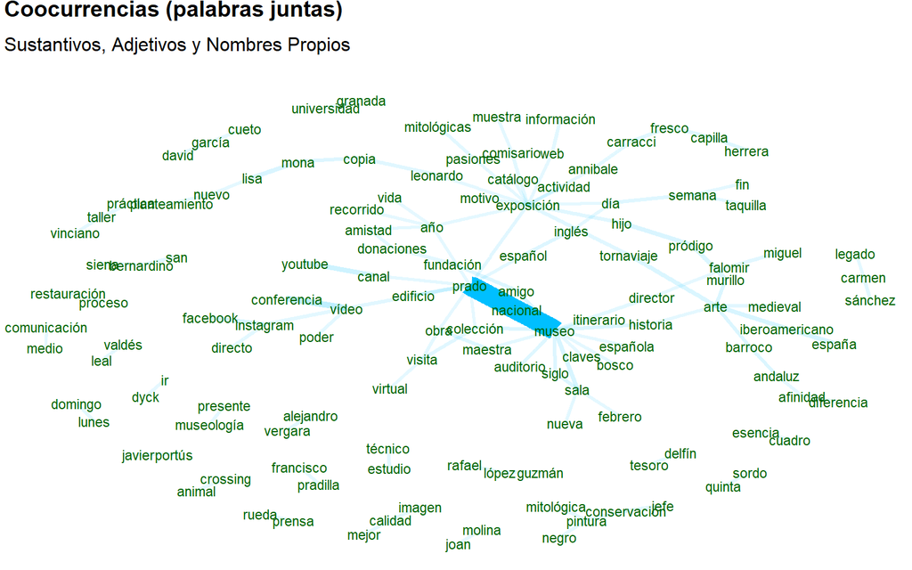

```r
#Represento en un plano 2D cada unas de las palbras para ver las concurrencias que presentan cada unas (palabras juntas) más frecuentes
wordnetwork <- graph_from_data_frame(head(cooc_j, 120))
ggraph(wordnetwork, layout = "fr") +
  geom_edge_link(aes(width = cooc, edge_alpha = cooc), edge_colour = "deepskyblue") +
  geom_node_text(aes(label = name), col = "darkgreen", size = 3) +
  theme_graph(base_family = "sans") + theme(legend.position = "none") +
  labs(title = "Coocurrencias (palabras juntas)", subtitle = "Sustantivos, Adjetivos y Nombres Propios") +
  theme(plot.title = element_text(size = 14), plot.margin = margin(0,0,0,0))
```

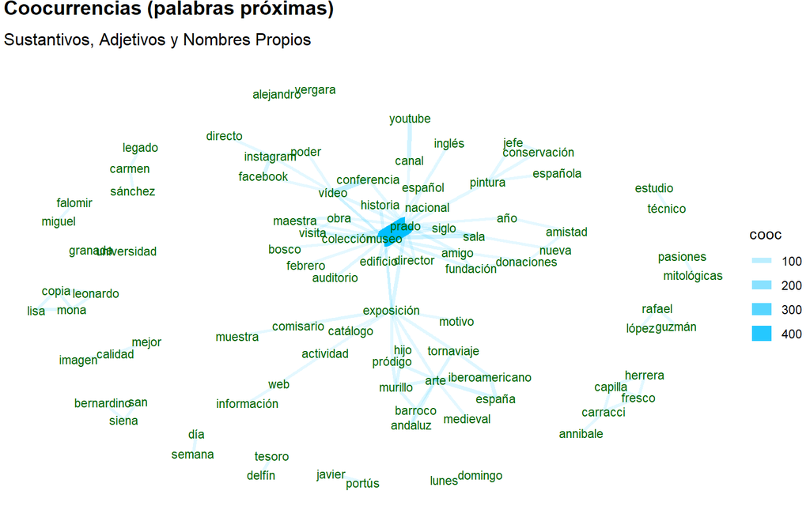

```r
#El gráfico anterior lo replico para reprentar las concurrencias de palabras próximas

cooc_p <- data.frame(cooccurrence(terminos$lemma, skipgram = 1))
# Visualizar coocurrencias
wordnetwork <- graph_from_data_frame(head(cooc_p, 120))
ggraph(wordnetwork, layout = "fr") +
  geom_edge_link(aes(width = cooc, edge_alpha = cooc), edge_colour = "deepskyblue") +
  geom_node_text(aes(label = name), col = "darkgreen", size = 3) +
  theme_graph(base_family = "sans") +
  labs(title = "Coocurrencias (palabras próximas)", subtitle = "Sustantivos, Adjetivos y Nombres Propios") +
  theme(plot.title = element_text(size = 14), plot.margin = margin(0,0,0,0))
```

## 4.6 Correlaciones

[figure not shown]

```r
terminos <- subset(x, upos %in% c("ADJ", "NOUN", "PROPN"))
terminos$id <- unique_identifier(terminos, fields = c("doc_id", "sentence_id"))

# Se genera una matriz de frecuencias de documentos
dtm <- document_term_frequencies(terminos, document = "id", term = "lemma")
dtm <- document_term_matrix(dtm)
dtm <- dtm_remove_lowfreq(dtm, minfreq = 18)
# Crear la matriz de correlación de términos
termcorr <- dtm_cor(dtm)
# Convertir esta matriz en un dataframe de coocurrencia
df <- as_cooccurrence(termcorr)
# "Grado de coocurrencia" superior a 0.2
df$cooc <- abs(df$cooc)
df <- subset(df, term1 < term2 & cooc > 0.2)
df <- df[order(df$cooc, decreasing=TRUE), ]
rownames(df) <- NULL

# Visualizar las correlaciones
# Se construye un grafo visual donde los nodos representan los términos y las aristas indican el grado de correlación entre ellos, con un diseño visual ajustado para mostrar los términos con mayor coocurrencia.
wordnetwork <- graph_from_data_frame(head(df, 120))
ggraph(wordnetwork, layout = "fr") +
  geom_edge_link(aes(width = cooc, edge_alpha = cooc), edge_colour = "deepskyblue") +
  geom_node_text(aes(label = name), col = "darkgreen", size = 3) +
  theme_graph(base_family = "sans") + theme(legend.position = "none") +
  labs(title = "Correlaciones", subtitle = "Sustantivos, Adjetivos y Nombres Propios") +
  theme(plot.title = element_text(size = 14), plot.margin = margin(0,0,0,0))
```

## 4.7 Clasificación tuits

```r
# Examinando las coocurrencias próximas obtenidas

# Analizo en primer lugar los lemmas exposición y pintor:

fil = subset(x, lemma %in% c("pintor","exposición"))
upos_fil = unique(fil$upos)
upos_fil
```

```
## [1] "NOUN"  "PROPN"
```

```r
#Obtengo que ambos lemas aparece tanto como sustantivo como nombre propio, por tanto:

# Tomo solo los upos anteriormente obtenidos:
terminos_Class <- subset(x, upos %in% c("NOUM", "PROPN"))
nombres <- unique(terminos_Class$lemma)

#Tomo las observaciones donde en ambos términos de la matriz coocurrencias haya un nombre propio y además, cuando uno de los términos sea exposición:
coocurrencias_pintores_p <- cooc_p %>%
  filter((term1 %in% nombres & term2 %in% nombres))

#Represento nuevamente estas coocurrencias:

colnames(coocurrencias_pintores_p)[3] <- "width"
coocurrencias_pintores_p$width <- scales::rescale(coocurrencias_pintores_p$width, to = c(0, 25))

wordnetwork <- graph_from_data_frame(head(coocurrencias_pintores_p, 150))
visIgraph(wordnetwork) %>%
  visEdges(color = list(color = "gray", highlight = "orange"),
                        arrows = list(to = list(enabled = FALSE))) %>%
  visNodes(size = 15, font = list(size = 22))
```

[interactive chart not shown]

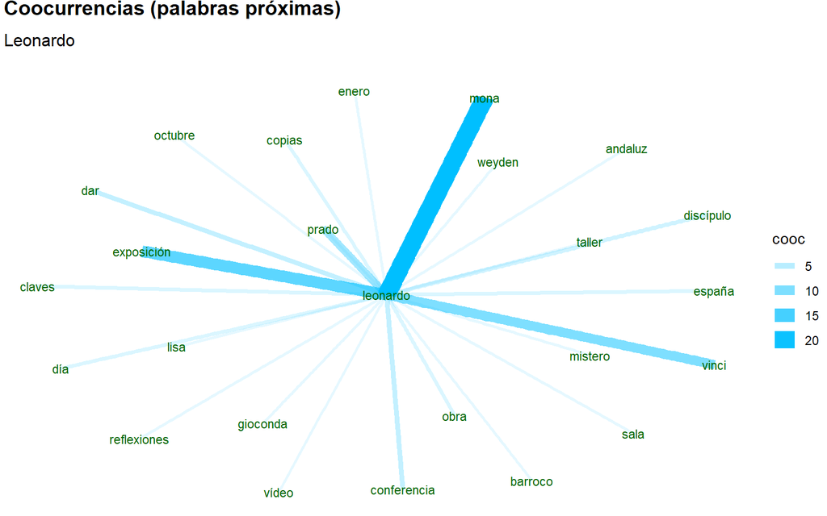

```r
# Dado este gráfico me centro en los pintores: Leonardo y Murillo:
# Comienzo con Leonardo:
coocurrencias_pintores_p_L <- cooc_p %>%
  filter((term1 %in% nombres & term2 %in% nombres) & (term1 == "leonardo" | term2 == "leonardo"))

#Represento nuevamente estas coocurrencias:

wordnetwork <- graph_from_data_frame(head(coocurrencias_pintores_p_L, 120))
ggraph(wordnetwork, layout = "fr") +
  geom_edge_link(aes(width = cooc, edge_alpha = cooc), edge_colour = "deepskyblue") +
  geom_node_text(aes(label = name), col = "darkgreen", size = 3) +
  theme_graph(base_family = "sans") +
  labs(title = "Coocurrencias (palabras próximas)", subtitle = "Leonardo") +
  theme(plot.title = element_text(size = 14), plot.margin = margin(0,0,0,0))
```

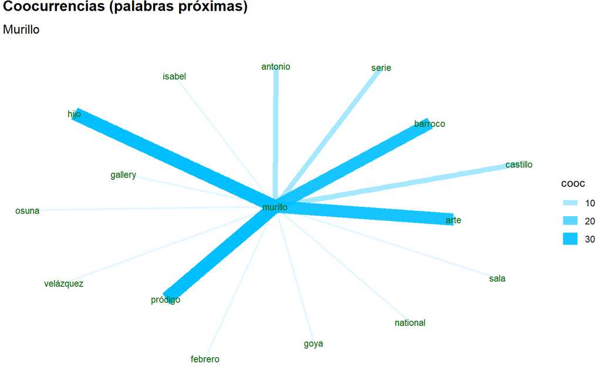

```r
# Prosigo con Murillo:
coocurrencias_pintores_p_M <- cooc_p %>%
  filter((term1 %in% nombres & term2 %in% nombres) & (term1 == "murillo" | term2 == "murillo"))

#Represento nuevamente estas coocurrencias:

wordnetwork <- graph_from_data_frame(head(coocurrencias_pintores_p_M, 120))
ggraph(wordnetwork, layout = "fr") +
  geom_edge_link(aes(width = cooc, edge_alpha = cooc), edge_colour = "deepskyblue") +
  geom_node_text(aes(label = name), col = "darkgreen", size = 3) +
  theme_graph(base_family = "sans") +
  labs(title = "Coocurrencias (palabras próximas)", subtitle = "Murillo") +
  theme(plot.title = element_text(size = 14), plot.margin = margin(0,0,0,0))
```

De los gráficos anteriores se pueden sacar las siguientes temáticas:

· leonardo - mona - lisa · leonardo - vinci · leonardo - exposición · leonardo - prado - conferencia · murillo - hijo - pródigo - exposición · murillo - antonio - serie - castillo · murillo - arte - barroco - andaluz · murillo - castillo - valdés - técnico · murillo - castillo - leal - técnico

Paso ahora a analizar la cadena de texto Tornaviaje

```r
#Selecciono tuits donde figura en el texto: el hashtag #Tornaviaje o la cadena de texto "Tornaviaje"

tornav = prado %>%
  filter(grepl("#Tornaviaje", text) | grepl("Tornaviaje", text))

#Elimino duplicidades:

tornav <- tornav %>%
  distinct()

# Se ordenan las observaciones en función de la varaible created_at:

tornav <- tornav %>%
  arrange(created_at) %>% select (-textmining)

# Obtengo los cinco primero tuits más anteigüos

head(tornav,5) %>% kbl(caption = "Primeros tuits relacionados con la exposición de Tornaviaje") %>% kable_minimal()
```

Primeros tuits relacionados con la exposición de Tornaviaje

| created_at | text |
| --- | --- |
| 2021-04-20 10:57:19 | Como avance de la gran exposición “Tornaviaje”, el Museo del Prado ha restaurado este biombo, una pieza capital del arte virreinal que ya se puede visitar en la sala 16A dentro del programa “La obra i… |
| 2021-09-10 11:37:00 | Próximas exposiciones en el Museo del Prado: “Donaciones de la Fundación Amigos del Museo del Prado”, “El Hijo pródigo de Murillo y el arte de narrar en el Barroco andaluz”, “Leonardo y la copia de Mo… |
| 2021-10-04 08:33:38 | Sigue en directo la rueda de prensa de la exposición “Tornaviaje. Arte Iberoamericano en España”. A las 11h en nuestro canal de YouTube https://t.co/DZsYI6LlKN #Tornaviaje https://t.co/9SlnD01L6P |
| 2021-10-04 09:08:25 | Sigue en directo la rueda de prensa de la exposición “Tornaviaje. Arte iberoamericano en España”, a través de nuestro canal de YouTube https://t.co/rbk9RMK3Ff #Tornaviaje https://t.co/cO3qXLvWR1 |
| 2021-10-04 10:36:19 | Hoy se ha presentado la exposición “#Tornaviaje. Arte iberoamericano en España”, sobre las obras de arte que llegaron desde América a España durante la Edad Moderna. La muestra se podrá visitar hasta … |

Paso ahora a analizar las cadenas de texto #HijoPródigoMurillo y Murillo

```r
hijo_prodigo_murillo = prado %>%
  filter(grepl("#HijoPródigoMurillo", text) | grepl("Murillo", text))

#Elimino duplicidades:

hijo_prodigo_murillo <- hijo_prodigo_murillo %>%
  distinct()

# Se ordenan las observaciones en función de la varaible created_at:

hijo_prodigo_murillo <- hijo_prodigo_murillo %>%
  arrange(created_at) %>% select (-textmining)

# Obtengo los cinco primero tuits más anteigüos

head(hijo_prodigo_murillo,5) %>% kbl(caption = "Primeros tuits relacionados la exposición de Murillo del Hijo Pródigo") %>% kable_minimal()
```

Primeros tuits relacionados la exposición de Murillo del Hijo Pródigo

| created_at | text |
| --- | --- |
| 2021-02-12 16:21:00 | Serie #ArteIncómodo: Amaya Alzaga, profesora de Historia del Arte en la UNED, comenta la “Sagrada Familia del pajarito” (copia de Murillo) de Isabel II (1848) https://t.co/KCM04XGCcx |
| 2021-09-10 11:37:00 | Próximas exposiciones en el Museo del Prado: “Donaciones de la Fundación Amigos del Museo del Prado”, “El Hijo pródigo de Murillo y el arte de narrar en el Barroco andaluz”, “Leonardo y la copia de Mo… |
| 2021-09-20 09:02:39 | En unos minutos comenzará la rueda de prensa de la exposición “El Hijo pródigo de Murillo y el arte de narrar del Barroco andaluz”. Os animamos a seguirla en directo en https://t.co/ZBcfCB2Kr0 https:/… |
| 2021-09-20 10:56:24 | Hoy se ha presentado a los medios de comunicación la exposición “El Hijo pródigo de Murillo y el arte de narrar del Barroco andaluz”. La muestra, que cuenta con la colaboración de la @ComunidadMadrid,… |
| 2021-09-20 11:25:15 | Hoy a las 18h os animamos a seguir la inauguración de la exposición “El Hijo pródigo de Murillo y el arte de narrar del Barroco andaluz”, en directo, a través de nuestros perfiles de Instagram (@museo… |